# Análise e testes de Hipótese com R

# Importando bibliotecas

```r
# Load libraries
library(ggplot2) # visualization
library(dplyr)   # data manipulation
library(repr)    # used only to change default figure size
# Change figure size
options(repr.plot.width=6, repr.plot.height=4)
```

# 1. Defina as hipóteses

> “O primeiro passo é indicar as hipóteses nulas e alternativas relevantes. Isso é importante, uma vez que a afirmação errônea das hipóteses prejudicará o resto do processo”

Aqui estão alguns exemplos de hipóteses gerais:

- “Esta moeda é justa”.
- “Os cientistas de dados preferem mais Python do que R.”

Em seguida, expresse a hipótese que você deseja investigar como:

- Uma hipótese nula H0 que representa alguma posição padrão, e
- Uma hipótese alternativa H1 com a qual vamos comparar H0.

Outra maneira de pensar nisso é que queremos comparar um grupo experimental e um grupo de controle. Declarado desta forma:

- A hipótese nula afirma que não há diferença entre os grupos e
- A hipótese alternativa afirma que existe uma diferença estatisticamente significante entre os grupos.

## Exemplo: Considere a variável de idade do conjunto de dados Titanic

Nós soubemos que as mulheres e as crianças foram convidadas a entrar nas embarcações salva-vidas primeiro quando o Titanic estava afundando. Então, vamos investigar a hipótese geral de que as crianças a bordo do Titanic tiveram melhores chances de sobrevivência do que os adultos. Eles fizeram?

Para responder a isso, podemos fazer um teste de hipóteses comparando duas proporções: a proporção de crianças que sobreviveram, $P{child}$ e a proporção de adultos que sobreviveram, $P{adult}$.

Podemos indicar as hipóteses nulas e alternativas como:

$H_{0}$: $P{child}$- $P{adult}$ = 0 : *Não há diferença significativa na proporção de crianças que sobrevivem e na proporção de adultos que sobrevivem*

$H_{A}$: $P{child}$ - $P{adult}$ > 0 *Existe uma melhor chance de sobrevivência para crianças do que adultos.*

- $P{child}$ *é a nossa proporção de população desconhecida de crianças que sobreviveram*
- $P{adult}$ *é a nossa proporção de população desconhecida de adultos que sobreviveram*

Nosso parâmetro de interesse é a diferença entre as proporções de todos os passageiros infantis e todos os passageiros adulta que sobreviveram: $P{child}$- $P{adult}$. Nossa estimativa pontual é a diferença entre as proporções de passageiros infantis amostrados (sampled) e os passageiros adultos amostrados que sobreviveram: $Pˆ{child}$ - $Pˆ{adult}$.

# 2. Verificar hipóteses e condições

“O segundo passo é considerar os pressupostos estatísticos sobre a amostra ao fazer o teste, por exemplo, pressupostos sobre a independência estatística ou sobre a forma das distribuições das observações. Isto é igualmente importante, pois pressupostos inválidos significarão que a Os resultados do teste são inválidos”. - Wikipedia

No teste de hipóteses, os grupos “controle” e “experimental” são tipicamente definidos através de um cuidadoso projeto experimental. Este não é geralmente o caso em aplicações de ciência dos dados, no entanto.

Uma exceção é coletar dados de clique em um teste A / B que mede o efeito da nova colocação de anúncios em seu site em comparação com o grupo de controle ou a colocação existente.

**Aqui estão as condições de inferência para comparar duas proporções independentes:**

1. Independência:

**Dentro de grupos:** as observações amostradas devem ser independentes dentro de cada grupo - Amostra / atribuição aleatória - Se amostragem sem substituição, n < 10% da população **Entre grupos:** os dois grupos devem ser independentes uns dos outros (não emparelhados)

2. Tamanho da amostra / inclinação: cada amostra deve atender a condição de falha de sucesso:

$n{child}$ $p{child}$ ≥ 10 e $n{child}$(1− $p{child}$)≥10

$n {adult}$ $p{adult}$ ≥ 10 e $n{adult}$(1− $p{adult}$)≥10

Note-se que para o cálculo do intervalo de confiança precisamos usar os valores de “pˆ” correspondentes às proporções observadas da amostra.

Agora vamos verificar essas condições para nossa amostra:

**Confira a independência:**

**Verificar dentro de grupos:**

A amostra deve ser aleatória tanto para adultos como para crianças, já que queremos tirar dados de train.csv e trabalhar com isso, ou amostrar aleatoriamente os dados nós mesmos.

Para atender a condição de 10%, precisamos estimar quantos filhos e quantos adultos estão na população de passageiros do Titanic.

- Vamos dar uma pausa para ver os dados do Titanic, para que possamos verificar a condição de 10%, depois continuar com os outros cchecks.

### Load the Titanic training data set:

```r
train <- read.csv("Titanic/train.csv")  # read in Titanic training data csv file to R data frame
str(train)                           # display data frame using R `str` function
```

```
'data.frame':   891 obs. of  12 variables:
 $ PassengerId: int  1 2 3 4 5 6 7 8 9 10 ...
 $ Survived   : int  0 1 1 1 0 0 0 0 1 1 ...
 $ Pclass     : int  3 1 3 1 3 3 1 3 3 2 ...
 $ Name       : Factor w/ 891 levels "Abbing, Mr. Anthony",..: 109 191 354 273 16 555 516 625 413 577 ...
 $ Sex        : Factor w/ 2 levels "female","male": 2 1 1 1 2 2 2 2 1 1 ...
 $ Age        : num  22 38 26 35 35 NA 54 2 27 14 ...
 $ SibSp      : int  1 1 0 1 0 0 0 3 0 1 ...
 $ Parch      : int  0 0 0 0 0 0 0 1 2 0 ...
 $ Ticket     : Factor w/ 681 levels "110152","110413",..: 524 597 670 50 473 276 86 396 345 133 ...
 $ Fare       : num  7.25 71.28 7.92 53.1 8.05 ...
 $ Cabin      : Factor w/ 148 levels "","A10","A14",..: 1 83 1 57 1 1 131 1 1 1 ...
 $ Embarked   : Factor w/ 4 levels "","C","Q","S": 4 2 4 4 4 3 4 4 4 2 ...
```

O conjunto de dados de treinamento é uma amostra aleatória de 891 passageiros do total de 1309 passageiros em nosso conjunto de dados. Este é pouco mais de 67% dos 1317 passageiros a bordo do Titanic quando afundou.

Já podemos ver que provavelmente não cumpriremos a condição de 10%, pois carregamos dados em mais da metade dos passageiros.

Vamos descobrir quantas crianças, $N{child}$ e quantos adultos, $N{adult}$, estão em todo o conjunto de dados (arquivos train.csv e test.csv) ou população:

```r
# THE ENTIRE POPULATION
test  <- read.csv('Titanic/test.csv')   # read in Titanic test data csv file
training <- data.frame(train$Age, train$Sex, train$Pclass)  # disclude Survived and assign to new data frame so we don't lose "train"
names(training) <- c("Age", "Sex","Pclass") # rename column variables
testing <- data.frame(test$Age, test$Sex, test$Pclass)
names(testing)  <- c("Age", "Sex","Pclass")
full  <- bind_rows(training, testing)      # bind training & test data
str(full)  # note that there are 1309 observations, which is over 99% of the entire population of 1317
```

```
'data.frame':   1309 obs. of  3 variables:
 $ Age   : num  22 38 26 35 35 NA 54 2 27 14 ...
 $ Sex   : Factor w/ 2 levels "female","male": 2 1 1 1 2 2 2 2 1 1 ...
 $ Pclass: int  3 1 3 1 3 3 1 3 3 2 ...
```

Primeiro, verifique se há valores faltantes de Idade:

```r
full <- full[!is.na(full$Age),] # drop all rows with missing ages
str(full)
```

```
'data.frame':   1046 obs. of  3 variables:
 $ Age   : num  22 38 26 35 35 54 2 27 14 4 ...
 $ Sex   : Factor w/ 2 levels "female","male": 2 1 1 1 2 2 2 1 1 1 ...
 $ Pclass: int  3 1 3 1 3 1 3 3 2 3 ...
```

Na verdade, temos apenas idades para **1046** passageiros, que são cerca de **79%** da população total de **1317** passageiros.

Vamos proceder a estimar $N{child}$ e $N{adult}$ com base nesses 1046 passageiros, então ampliá-los por um fator de 1317/1046, ou ≈1.259

Mas primeiro vamos dar uma olhada na distribuição das idades dos passageiros:

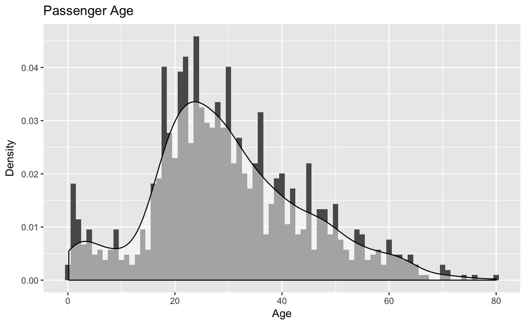

```r
# Overlay a probability distribution function (PDF) on a histogram of Age
ggplot(full, aes(x=Age)) +
    ggtitle("Passenger Age") +
    xlab("Age") +
    ylab("Density") +
    geom_histogram(aes(y=..density..), binwidth=1)+
    geom_density(alpha=.5, fill="#FFFFFF")
```

```r
min(full$Age) * 12 # convert from years to months
```

```
[1] 2.04
```

```r
max(full$Age)
```

```
[1] 80
```

O passageiro mais jovem nesta amostra tinha 2 meses de idade e o mais velho tinha 80 anos, o que parece bastante mais antigo do que a expectativa de vida média de início a meados dos anos 50 para o ano de 1912 quando o Titanic afundou.

Embora, obviamente, a distribuição das eras numéricas não seja normalmente distribuída, podemos examinar as discrepâncias em idades extremas com um enredo de quantile normal.

Os dados são visivelmente distorcidos, embora haja um mergulho claro no número de passageiros pré-adolescentes e adolescentes.

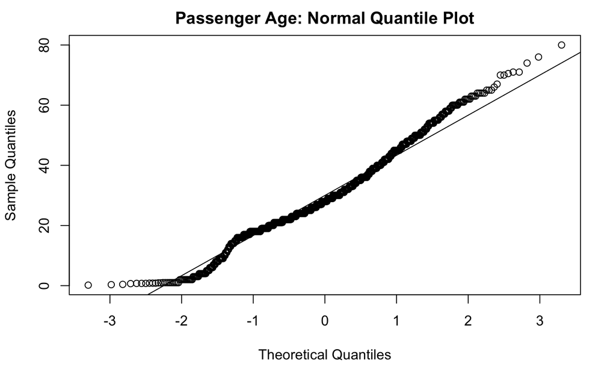

```r
qqnorm(full$Age, main="Passenger Age: Normal Quantile Plot")
qqline(full$Age)
```

Agora vamos discretizar os valores da coluna Age numérica em dois grupos:

```r
# Add a new categorical variable called "AgeGroup" with values "Child" or "Adult".
full$AgeGroup <- "Adult"
full$AgeGroup[full$Age < 18] <- "Child"
```

```r
table(full$AgeGroup)
```

```
Adult Child
  892   154
```

```r
table(full$AgeGroup) * 1.259 # scale up values so total is 1317
```

```
   Adult    Child
1123.028  193.886
```

Então, estimaremos $N{child}$≈194 e $N{adult}$≈1123. Isso significa que nossos tamanhos de amostra devem ser $n{child}$ < 19 e $n{adult}$ < 112 para o critério de 10% para a independência.

Subconjunto, descarte linhas com valores de idade que faltam, em seguida, tire uma amostra aleatória do quadro de dados do treino de ≲10%:

```r
train <- data.frame(train$Survived, train$Age, train$Sex, train$Pclass); # select 4 columns of data frame
names(train) <- c("Survived", "Age", "Sex","Pclass"); # rename columns from, e.g., train$Survived to Survived
# Let's keep the data frame "train" intact for later use, and create a new one called "train_age"
train_age <- train[!is.na(train$Age),] # strip "train" data of rows with Age=NULL
summary(train_age$Age)                 # show some descriptive statistics of Age variable
```

```
   Min. 1st Qu.  Median    Mean 3rd Qu.    Max.
   0.42   20.12   28.00   29.70   38.00   80.00
```

```r
mysample <- train_age[sample(1:nrow(train_age), 115, replace=FALSE),]
str(mysample)
```

```
'data.frame':   115 obs. of  4 variables:
 $ Survived: int  1 0 0 0 0 0 0 1 1 0 ...
 $ Age     : num  17 24 22 43 36 33 28 31 4 47 ...
 $ Sex     : Factor w/ 2 levels "female","male": 1 2 1 2 2 2 2 2 2 2 ...
 $ Pclass  : int  3 3 3 2 3 3 3 3 3 1 ...
```

Discreva as idades em mysample em dois grupos - adultos e crianças - e verifique a condição:

```r
length(which(mysample$Age < 18))
```

```
[1] 15
```

```r
length(which(mysample$Age >= 18))
```

```
[1] 100
```

Um tamanho de amostra de n = 115 trabalhou.

```r
# Add a new categorical variable called "AgeGroup" with values "Child" or "Adult".
mysample$AgeGroup <- "Adult"
mysample$AgeGroup[mysample$Age < 18] <- "Child"
```

```r
# Add a new categorical variable called "Lived" with "Yes" or "No" instead of "1" or "0" for Survival.
mysample$Lived[ mysample$Survived == 1 ] <- "Yes"
mysample$Lived[ mysample$Survived == 0 ] <- "No"
# Return a contingency table of the new Lived column.
lived <- table( mysample$Lived )
lived
```

```
 No Yes
 67  48
```

```r
# Create a contingency table with proportions.
percent_lived <- round( 100*prop.table( lived ), 2 )
percent_lived
```

```
   No   Yes
58.26 41.74
```

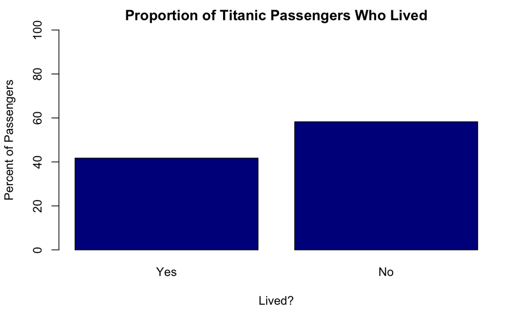

```r
# Let's plot that for fun
barplot(sort(percent_lived, decreasing=FALSE),
        main="Proportion of Titanic Passengers Who Lived",
        xlab="Lived?",
        ylab="Percent of Passengers",
        col="darkblue",
        ylim=c(0,100)
        )
```

Faça tabelas de freqüência e proporção de sobrevivência crianças / adulto:

```r
# `table` creates a contingency table
age_group_lived <- table(mysample$AgeGroup, mysample$Lived)
age_group_lived
```

```
        No Yes
  Adult 58  42
  Child  9   6
```

```r
# `prop.table` gives the row percentages
age_group_lived_prop <- prop.table(age_group_lived, margin=1) # 1 = rows, 2 = columns
age_group_lived_prop
```

```
          No  Yes
  Adult 0.58 0.42
  Child 0.60 0.40
```

P/ Satisfazer o topico (2):

```r
(age_group_lived[3] + age_group_lived[4]) * age_group_lived_prop[4]
```

```
[1] 19.2
```

```r
(age_group_lived[3] + age_group_lived[4]) * (1 - age_group_lived_prop[4])
```

```
[1] 28.8
```

```r
(age_group_lived[1] + age_group_lived[2]) * age_group_lived_prop[2]
```

```
[1] 40.2
```

```r
(age_group_lived[1] + age_group_lived[2]) * (1 - age_group_lived_prop[2])
```

```
[1] 26.8
```

# 3. Teste Estat’ístico e o valor P

“Decida qual teste é apropriado e indique a estatística de teste relevante”. - Wikipedia

Uma vez que estamos testando a igualdade de proporções entre 2 amostras, seria apropriado usar o teste Xˆ2 (Chi-quadrado) como nossa estatística de teste.

“Calcule a partir das observações o valor observado da estatística de teste”. - Wikipedia

“Calcule o valor de p. Esta é a probabilidade, sob a hipótese nula, de amostrar uma estatística de teste pelo menos tão extrema quanto a que foi observada”. - Wikipedia

```r
# chi-squared test between Survived, Age
chisq.test(mysample$Survived, mysample$AgeGroup)
```

```
    Pearson's Chi-squared test with Yates' continuity correction

data:  mysample$Survived and mysample$AgeGroup
X-squared = 1.26e-31, df = 1, p-value = 1
```

# 4. Tomar uma decisão e interpretá-la no contexto da questão de pesquisa

“Rejeitar a hipótese nula, em favor da hipótese alternativa, se e somente se o valor de p for menor que o limite de nível de significância (probabilidade selecionada)”. - Wikipedia

Se p-value<α, rejeitar \ $H{0}$, os dados fornecem evidências para \ $H{A}$ Se p-value>α, não rejeite $H{0}$, os dados não fornecem evidência de $H{A}$

Um p-valor quase zero indica que a evidência apóia a hipótese alternativa de que as crianças são mais propensas a ter sobrevivido. No entanto, temos um p-valor de 1.

Portanto, não rejeitamos a hipótese nula.

Existe uma chance de 100% de observar uma estatística tão extrema se nossa hipótese nula for verdadeira.

## Exemplo: Considere a variável sexo

```r
chisq.test(mysample$Survived, mysample$Sex)
```

```
    Pearson's Chi-squared test with Yates' continuity correction

data:  mysample$Survived and mysample$Sex
X-squared = 36.903, df = 1, p-value = 1.241e-09
```

Um p-valor quase zero indica que a evidência apóia a hipótese alternativa de o sexo define as chances de sobrevivência.

Então, rejeitamos a hipótese nula.

Há uma chance (basicamente) de 0% de que você observaria uma estatística tão extrema se nossa hipótese nula fosse verdadeira.

OUTRAS REFERENCIAS

https://rpubs.com/jeffrey6557/52266 https://www.analyticsvidhya.com/blog/2015/10/inferential-descriptive-statistics-beginners-r/ https://www.analyticsvidhya.com/blog/2015/09/hypothesis-testing-explained/